# Prediction Assignment

A Coursera JHU Data Science Specialization Class Project

Manuel Esteban-Infantes

This document is a project for peer review as part of the Machine Learning course, within the JHU Data Science Specialization program. The goal is to predict the manner in which a group of individuals perform certain exercise, from data captured by wearable sensors.

It has been generated with Knitr within RStudio. For readability purposes, all code is executed before hand in an embedded R block with the options >eval = TRUE, echo = FALSE, message = FALSE. All source code is included as an appendix, and the source Rmd file with ther embedded code is [avaible in gitHub](https://github.com/mei128/PredictionAssignment).

Packages used include caret, gbm, and randomForest.

## Getting and Cleaning Data

Data is obtained from the provided sources (see credits). A first look at data shows a large number of empty, #DIV/0, and NA values. All variables with a large number of NAs are statistic summaries of sensor data (avg, max, min, ammplitude, var, stddev, kurtosis). The high percentage of NAs in those variables (over 97%) does not make them suitable predictors, and are dropped from both sets.

The dataset still contains variables with no predictive value, descriptive of the context but not of the activity being performed, like the index, subject id, the new window flag, or the timestamps. These six variables are removed from both datasets.

```r
# Load data

baseURL      <- "https://d396qusza40orc.cloudfront.net/predmachlearn/"
trainingFile <- "pml-training.csv"
testingFile  <- "pml-testing.csv"

sourceData <- function(fname) {
    fpath <- paste0("./data/",fname)
    furl  <- paste0(baseURL,fname)
    if (!file.exists("./data"))  { dir.create("./data") }
    if (!file.exists(fpath))     { download.file(furl, fpath, method = "curl") }
    read.csv(fpath,na.strings = c("","NA","#DIV/0!"))
}

trainingSet <- sourceData(trainingFile)
testingSet  <- sourceData(testingFile)

# Drop majority NAs
allNA    <- apply(trainingSet,2,function(x) sum(is.na(x)))
allNA    <- allNA > 0.97*length(trainingSet$X)
allNA[1] <- TRUE # Patch X out
trainingSet <- trainingSet[,!allNA]
testingSet  <- testingSet[,!allNA]

# Drop variables with no predcitive value
noPred<-which(names(trainingSet) %in% c("X","user_name","raw_timestamp_part_1",
                                        "raw_timestamp_part_2","cvtd_timestamp","new_window"))
trainingSet <- trainingSet[,-noPred]
testingSet  <- testingSet[,-noPred]
```

The outcome variable, classe, appears sorted along the index, what creates the false impression of some structure in data when plotting some variables colored by outcome (coloring takes place in an ordered manner). To avoid this artifact the dataset is reshuffled (this is not necessary in the testing set).

```r
set.seed(12358)

# Reshuflle data set
trainingSet <- trainingSet[sample(length(trainingSet$classe)),]
# Pre-train subset
inSubSet    <- createDataPartition(trainingSet$classe, p = 0.1, list=FALSE)
subSet      <- trainingSet[inSubSet,]
inPreTrain  <- createDataPartition(subSet$classe, p=0.8, list=FALSE)
preTrainSet <- subSet[ inPreTrain,]
preTestSet  <- subSet[-inPreTrain,]
```

## Exploratory Data Analysis

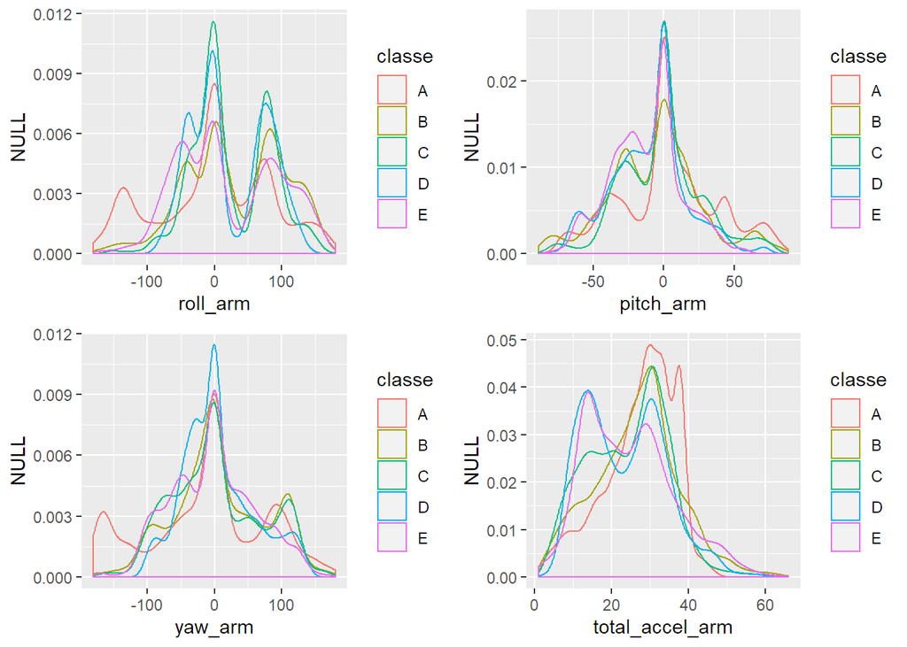

```r
q1 <- qplot(roll_arm,data=trainingSet,geom="density", col=classe)
q2 <- qplot(pitch_arm,data=trainingSet,geom="density", col=classe)
q3 <- qplot(yaw_arm,data=trainingSet,geom="density", col=classe)
q4 <- qplot(total_accel_arm,data=trainingSet,geom="density", col=classe)
grid.arrange(q1, q2, q3, q4, nrow=2, ncol=2)
```

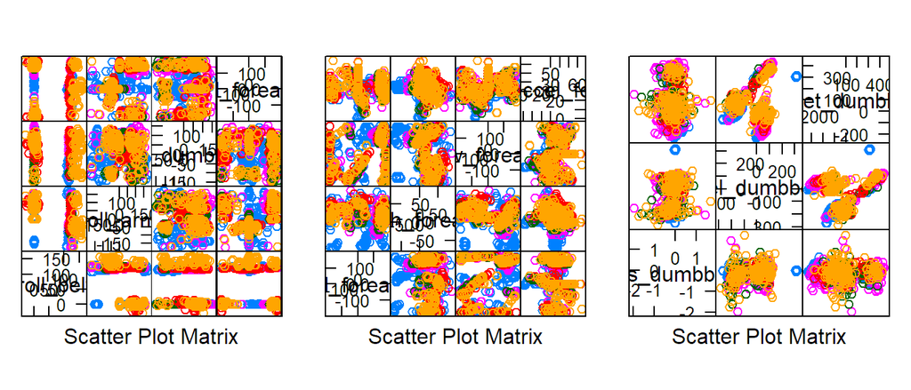

```r
smpset <- sample(length(trainingSet$classe),1000)
edaset <- grep("roll_",names(trainingSet))
f1 <- featurePlot(x=trainingSet[smpset,edaset],y=trainingSet$classe[smpset],plot="pairs")
edaset <- grep("_forearm$",names(trainingSet))
f2 <- featurePlot(x=trainingSet[smpset,edaset],y=trainingSet$classe[smpset],plot="pairs")
edaset <- grep("_dumbbell_z",names(trainingSet))
f3 <- featurePlot(x=trainingSet[smpset,edaset],y=trainingSet$classe[smpset],plot="pairs")
grid.arrange(f1, f2, f3, nrow=1, ncol=3)
```

## Cross Validation

Cross validation was performed using caret’s built-in repeated cross validation, with 3 repetitions of 10 k-folds. A larger number of repetitions did not increase the accuracy. In order to improve performance and reduce the risk of overfitting, we identified the number of random predictors to be included in the random forests mehod that yielded the least error using the function rfcv from the randomForest package.

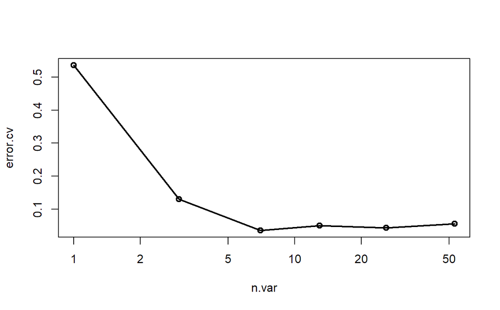

```r
resultCV <- rfcv(preTrainSet[,-54],preTrainSet$classe)
with(resultCV, plot(n.var, error.cv, log="x", type="o", lwd=2))
```

```r
mtry     <- resultCV$n.var[which.min(resultCV$error.cv)]
tgrid    <- expand.grid(.mtry = mtry)
control  <- trainControl(method="repeatedcv", number=10, repeats=3)
```

The number of variables used is 7.

## Method selection

Two models were trained using boosting (gbm) and random forests (rf) with the reduced training and validation sets.

```r
modelRF  <- train(classe~., data=preTrainSet, method="rf",
                metric = "Accuracy", trControl = control, tuneGrid = tgrid, prox = TRUE)
predRF   <- predict(modelRF, preTestSet)

modelGBM <- train(classe~., data=preTrainSet, method="gbm",
                metric = "Accuracy", trControl = control, verbose = FALSE)
predGBM  <- predict(modelGBM,preTestSet)

comparison <- resamples(list(RF=modelRF,BOOSTING=modelGBM))
summary(comparison)
```

```
##
## Call:
## summary.resamples(object = comparison)
##
## Models: RF, BOOSTING
## Number of resamples: 30
##
## Accuracy
##               Min.   1st Qu.    Median     Mean   3rd Qu.      Max. NA's
## RF       0.9044586 0.9487996 0.9551264 0.954859 0.9666807 0.9810127    0
## BOOSTING 0.8789809 0.9295995 0.9426752 0.941720 0.9600779 0.9873418    0
##
## Kappa
##               Min.   1st Qu.    Median      Mean   3rd Qu.      Max. NA's
## RF       0.8789639 0.9352613 0.9432093 0.9428572 0.9578338 0.9760036    0
## BOOSTING 0.8464113 0.9108186 0.9274398 0.9262297 0.9495263 0.9839732    0
```

Random forests showed better mean and median accuracies, with boosting showing maximum better accuracy, but we look for better accuracy all over the set, hence we settled for random forests to train the final model.

## Final training and prediction

The training set was split using 80% to train the final model and 20% for validation and estimation of the out of sample error, and a model was produced using random forests method with the same tuning as before.

```r
# Training  - final

inFinal    <- createDataPartition(trainingSet$classe, p = 0.8, list=FALSE)
trainFinal <- trainingSet[ inFinal,]
 testFinal <- trainingSet[-inFinal,]

model      <- train(classe~., data=trainFinal, method="rf",
                   metric = "Accuracy", trControl = control, tuneGrid = tgrid, prox = TRUE)

model$finalModel
```

```
##
## Call:
##  randomForest(x = x, y = y, mtry = param$mtry, proximity = TRUE)
##                Type of random forest: classification
##                      Number of trees: 500
## No. of variables tried at each split: 7
##
##         OOB estimate of  error rate: 0.19%
## Confusion matrix:
##      A    B    C    D    E class.error
## A 4464    0    0    0    0 0.000000000
## B    5 3032    1    0    0 0.001974984
## C    0    7 2731    0    0 0.002556611
## D    0    0   14 2559    0 0.005441119
## E    0    0    0    3 2883 0.001039501
```

The **trained model has an OOB (out of the bag) error of 0.19%** (accuracy 99.8%)

```r
validation <- predict(model,testFinal)

insample   <- confusionMatrix(validation,testFinal$classe)

insample$overall
```

```
##       Accuracy          Kappa  AccuracyLower  AccuracyUpper   AccuracyNull
##      0.9987255      0.9983878      0.9970282      0.9995860      0.2844762
## AccuracyPValue  McnemarPValue
##      0.0000000            NaN
```

However, With the validation set, **the accuracy was 99.87%**.

We finally applied the trained model to the provided testing set, obtaining the followind results:

```r
# Prediction - final

prediction <- predict(model, testingSet)
resultset  <- data.frame(problem_id=testingSet$problem_id, classe = prediction)
print(resultset)
```

```
##    problem_id classe
## 1           1      B
## 2           2      A
## 3           3      B
## 4           4      A
## 5           5      A
## 6           6      E
## 7           7      D
## 8           8      B
## 9           9      A
## 10         10      A
## 11         11      B
## 12         12      C
## 13         13      B
## 14         14      A
## 15         15      E
## 16         16      E
## 17         17      A
## 18         18      B
## 19         19      B
## 20         20      B
```

### Credits

Data for this exercise was sourced from:

Velloso, E.; Bulling, A.; Gellersen, H.; Ugulino, W.; Fuks, H. Qualitative Activity Recognition of Weight Lifting Exercises. Proceedings of 4th International Conference in Cooperation with SIGCHI (Augmented Human ’13). Stuttgart, Germany: ACM SIGCHI, 2013.

# Annex I - Source Code

This section includes the source code embedded in the document in a single block.

```r
library(caret)
library(gbm)
library(ggplot2)
library(randomForest)

# Load data

baseURL      <- "https://d396qusza40orc.cloudfront.net/predmachlearn/"
trainingFile <- "pml-training.csv"
testingFile  <- "pml-testing.csv"

sourceData <- function(fname) {
    fpath <- paste0("./data/",fname)
    furl  <- paste0(baseURL,fname)
    if (!file.exists("./data"))  { dir.create("./data") }
    if (!file.exists(fpath))     { download.file(furl, fpath, method = "curl") }
    read.csv(fpath,na.strings = c("","NA","#DIV/0!"))
}

trainingSet <- sourceData(trainingFile)
testingSet  <- sourceData(testingFile)

# Drop majority NAs
allNA    <- apply(trainingSet,2,function(x) sum(is.na(x)))
allNA    <- allNA > 0.97*length(trainingSet$X)
allNA[1] <- TRUE # Patch X out
trainingSet <- trainingSet[,!allNA]
testingSet  <- testingSet[,!allNA]

# Drop variables with no predcitive value
noPred<-which(names(trainingSet) %in% c("X","user_name","raw_timestamp_part_1","raw_timestamp_part_2","cvtd_timestamp","new_window"))
trainingSet <- trainingSet[,-noPred]
testingSet  <- testingSet[,-noPred]

set.seed(12358)

# Reshuflle data set
trainingSet <- trainingSet[sample(length(trainingSet$classe)),]


# Pre-train subset

inSubSet    <- createDataPartition(trainingSet$classe, p = 0.1, list=FALSE)
subSet      <- trainingSet[inSubSet,]
inPreTrain  <- createDataPartition(subSet$classe, p=0.8, list=FALSE)
preTrainSet <- subSet[ inPreTrain,]
preTestSet  <- subSet[-inPreTrain,]

# Exploration

q1 <- qplot(roll_arm,data=trainingSet,geom="density", col=classe)
q2 <- qplot(pitch_arm,data=trainingSet,geom="density", col=classe)
q3 <- qplot(yaw_arm,data=trainingSet,geom="density", col=classe)
q4 <- qplot(total_accel_arm,data=trainingSet,geom="density", col=classe)
grid.arrange(q1, q2, q3, q4, nrow=2, ncol=2)

smpset <- sample(length(trainingSet$classe),1000)
edaset <- grep("roll_",names(trainingSet))
f1 <- featurePlot(x=trainingSet[smpset,edaset],y=trainingSet$classe[smpset],plot="pairs")
edaset <- grep("_forearm$",names(trainingSet))
f2 <- featurePlot(x=trainingSet[smpset,edaset],y=trainingSet$classe[smpset],plot="pairs")
edaset <- grep("_dumbbell_z",names(trainingSet))
f3 <- featurePlot(x=trainingSet[smpset,edaset],y=trainingSet$classe[smpset],plot="pairs")
grid.arrange(f1, f2, f3, nrow=1, ncol=3)

# Cross validation set-up: determine best mtry

resultCV <- rfcv(preTrainSet[,-54],preTrainSet$classe)
with(resultCV, plot(n.var, error.cv, log="x", type="o", lwd=2))
mtry     <- resultCV$n.var[which.min(resultCV$error.cv)]
tgrid    <- expand.grid(.mtry = mtry)
control  <- trainControl(method="repeatedcv", number=10, repeats=3)

# Training subset

modelRF  <- train(classe~., data=preTrainSet, method="rf",
                metric = "Accuracy", trControl = control, tuneGrid = tgrid, prox = TRUE)
predRF   <- predict(modelRF, preTestSet)

modelGBM <- train(classe~., data=preTrainSet, method="gbm",
                metric = "Accuracy", trControl = control, verbose = FALSE)
predGBM  <- predict(modelGBM,preTestSet)

comparison <- resamples(list(RF=modelRF,BOOSTING=modelGBM))
summary(comparison)

# Training  - final

inFinal    <- createDataPartition(trainingSet$classe, p = 0.8, list=FALSE)
trainFinal <- trainingSet[ inFinal,]
 testFinal <- trainingSet[-inFinal,]

model      <- train(classe~., data=trainFinal, method="rf",
                    metric = "Accuracy", trControl = control, tuneGrid = tgrid, prox = TRUE)
validation <- predict(model,testFinal)

insample   <- confusionMatrix(validation,testFinal$classe)

insample$overall

# Prediction - final

prediction <- predict(model, testingSet)
resultset  <- data.frame(problem_id=testingSet$problem_id, classe = prediction)
print(resultset)
```